# IODS course project

Vojtěch Válek

# About the project

## Course description

> The first impressions of the course are **very good** and I am sure that the learning outcomes will be **very useful**. I am looking forward to learning how to work with R since I will need it during work on my bachelor thesis. After this course, I mainly expect to be able to work with large datasets and be able to run regressions on them. I already know some basics of programming in R, because I was learning it a little in my home school in Czechia. Anyway, I am here in Helsinki on Erasmus and one of the Finnish students recommended me this course, so I took it.

## GitHub repository

[link](https://github.com/VojtaV/IODS-project.git)

# Regression analysis and model validation

- Describe your work and results clearly.
- Assume the reader has an introductory course level understanding of writing and reading R code as well as statistical methods.
- Assume the reader has no previous knowledge of your data or the more advanced methods you are using.

## Task 1

imported_data <-read.csv(file=“learning2014.csv”)

str(imported_data)

dim(imported_data)

head(imported_data)

## Task 2

### Visualizing the data

pairs(imported_data)

pairs(imported_data[-1]) #scatter matrix of the variables without gender

### Alternatively: access the GGallz and ggplot2 libraries

install.packages(“GGally”)

install.packages(“ggplot2”)

library(GGally)

library(ggplot2)

p <- ggpairs(imported_data, mapping = aes(col = gender, alpha = 0.3), lower = list(combo = wrap(“facethist”, bins = 20)))

p

### Summary of the variables

summary(imported_data)

## Task 3

regression_model <- lm(Points ~ Attitude + Age + stra, data = imported_data)

summary(regression_model)

regression_model_adjusted <- lm(Points ~ Attitude, data = imported_data)

summary(regression_model_adjusted)

## Task 5

par(mfrow = c(2,2))

plot(regression_model_adjusted, which = c(1, 2, 5))

# Logistic regression

## Task 2

### Reading the data, printing the names of the variables in the data and exploring the structure and dimensions of the data

```r
data <- read.csv(file = "StudentData.csv")
colnames(data)
```

```
##  [1] "school"     "sex"        "age"        "address"    "famsize"
##  [6] "Pstatus"    "Medu"       "Fedu"       "Mjob"       "Fjob"
## [11] "reason"     "nursery"    "internet"   "traveltime" "studytime"
## [16] "failures"   "famrel"     "freetime"   "goout"      "Dalc"
## [21] "Walc"       "health"     "absences"   "G1"         "G2"
## [26] "G3"         "alc_use"    "high_use"   "guardian"   "schoolsup"
## [31] "famsup"     "paid"       "activities" "higher"     "romantic"
```

```r
summary(data)
```

```
##  school   sex          age        address famsize   Pstatus
##  GP:342   F:198   Min.   :15.00   R: 81   GT3:278   A: 38
##  MS: 40   M:184   1st Qu.:16.00   U:301   LE3:104   T:344
##                   Median :17.00
##                   Mean   :16.59
##                   3rd Qu.:17.00
##                   Max.   :22.00
##       Medu            Fedu             Mjob           Fjob
##  Min.   :0.000   Min.   :0.000   at_home : 53   at_home : 16
##  1st Qu.:2.000   1st Qu.:2.000   health  : 33   health  : 17
##  Median :3.000   Median :3.000   other   :138   other   :211
##  Mean   :2.806   Mean   :2.565   services: 96   services:107
##  3rd Qu.:4.000   3rd Qu.:4.000   teacher : 62   teacher : 31
##  Max.   :4.000   Max.   :4.000
##         reason    nursery   internet    traveltime      studytime
##  course    :140   no : 72   no : 58   Min.   :1.000   Min.   :1.000
##  home      :110   yes:310   yes:324   1st Qu.:1.000   1st Qu.:1.000
##  other     : 34                       Median :1.000   Median :2.000
##  reputation: 98                       Mean   :1.448   Mean   :2.037
##                                       3rd Qu.:2.000   3rd Qu.:2.000
##                                       Max.   :4.000   Max.   :4.000
##     failures          famrel         freetime        goout
##  Min.   :0.0000   Min.   :1.000   Min.   :1.00   Min.   :1.000
##  1st Qu.:0.0000   1st Qu.:4.000   1st Qu.:3.00   1st Qu.:2.000
##  Median :0.0000   Median :4.000   Median :3.00   Median :3.000
##  Mean   :0.2016   Mean   :3.937   Mean   :3.22   Mean   :3.113
##  3rd Qu.:0.0000   3rd Qu.:5.000   3rd Qu.:4.00   3rd Qu.:4.000
##  Max.   :3.0000   Max.   :5.000   Max.   :5.00   Max.   :5.000
##       Dalc            Walc           health         absences
##  Min.   :1.000   Min.   :1.000   Min.   :1.000   Min.   : 0.0
##  1st Qu.:1.000   1st Qu.:1.000   1st Qu.:3.000   1st Qu.: 1.0
##  Median :1.000   Median :2.000   Median :4.000   Median : 3.0
##  Mean   :1.482   Mean   :2.296   Mean   :3.573   Mean   : 4.5
##  3rd Qu.:2.000   3rd Qu.:3.000   3rd Qu.:5.000   3rd Qu.: 6.0
##  Max.   :5.000   Max.   :5.000   Max.   :5.000   Max.   :45.0
##        G1              G2              G3           alc_use
##  Min.   : 2.00   Min.   : 4.00   Min.   : 0.00   Min.   :1.000
##  1st Qu.:10.00   1st Qu.:10.00   1st Qu.:10.00   1st Qu.:1.000
##  Median :12.00   Median :12.00   Median :12.00   Median :1.500
##  Mean   :11.49   Mean   :11.47   Mean   :11.46   Mean   :1.889
##  3rd Qu.:14.00   3rd Qu.:14.00   3rd Qu.:14.00   3rd Qu.:2.500
##  Max.   :18.00   Max.   :18.00   Max.   :18.00   Max.   :5.000
##   high_use         guardian   schoolsup famsup     paid     activities
##  Mode :logical   father: 91   no :331   no :144   no :205   no :181
##  FALSE:268       mother:275   yes: 51   yes:238   yes:177   yes:201
##  TRUE :114       other : 16
##
##
##
##  higher    romantic
##  no : 18   no :261
##  yes:364   yes:121
##
##
##
##
```

```r
str(data)
```

```
## 'data.frame':    382 obs. of  35 variables:
##  $ school    : Factor w/ 2 levels "GP","MS": 1 1 1 1 1 1 1 1 1 1 ...
##  $ sex       : Factor w/ 2 levels "F","M": 1 1 1 1 1 2 2 1 2 2 ...
##  $ age       : int  18 17 15 15 16 16 16 17 15 15 ...
##  $ address   : Factor w/ 2 levels "R","U": 2 2 2 2 2 2 2 2 2 2 ...
##  $ famsize   : Factor w/ 2 levels "GT3","LE3": 1 1 2 1 1 2 2 1 2 1 ...
##  $ Pstatus   : Factor w/ 2 levels "A","T": 1 2 2 2 2 2 2 1 1 2 ...
##  $ Medu      : int  4 1 1 4 3 4 2 4 3 3 ...
##  $ Fedu      : int  4 1 1 2 3 3 2 4 2 4 ...
##  $ Mjob      : Factor w/ 5 levels "at_home","health",..: 1 1 1 2 3 4 3 3 4 3 ...
##  $ Fjob      : Factor w/ 5 levels "at_home","health",..: 5 3 3 4 3 3 3 5 3 3 ...
##  $ reason    : Factor w/ 4 levels "course","home",..: 1 1 3 2 2 4 2 2 2 2 ...
##  $ nursery   : Factor w/ 2 levels "no","yes": 2 1 2 2 2 2 2 2 2 2 ...
##  $ internet  : Factor w/ 2 levels "no","yes": 1 2 2 2 1 2 2 1 2 2 ...
##  $ traveltime: int  2 1 1 1 1 1 1 2 1 1 ...
```

[output cut: 21 more lines]

```r
dim(data)
```

```
## [1] 382  35
```

> There are 382 observations and 35 variables in our dataset. The data showing achievements of students in secondary education of two Portuguese schools.We are using two datasets and trying to observe the performance of the students in mathematics and portuguese language with regard to consumption of alcohol and other social and school related features.

## Task 3

### 4 variables in the dataset and my hypothesis about their relationships with alcohol consumption

- failures: This numeric variable shows us how many classes each student failed in the past. My hypothesis is that with high alcohol consumption, the student will fail more classes that wit low alcohol consumption. On the other hand, variable which shows us how much alcohol student consume might increase when student pass the class (perhaps because he is celebrating successful exam) . This would imply that the alcohol consumption is actually higher when the number of failed classes is low. However, I still think that this will not be the case and that consumption of alcohol and number of failed classes are positively correlated.
- health: The higher the consumption of alcohol, the worse the health of a student will be.
- absences: This variable will be also positively correlated with consumption of alcohol, since students might be drinking instead of attending school. They may also have a hangover after a drinking evening and therefore not go to school.
- G3 (final grade): Final grand probably tend to be lower with higher consumption oc alcohol. However, similar thing as in the case oc variable “failures” may apply here. Students may be drinking after they receive a nice final grade.

## Task 4

### Distributions of chosen variables

```r
library(tidyr)
library(dplyr)
```

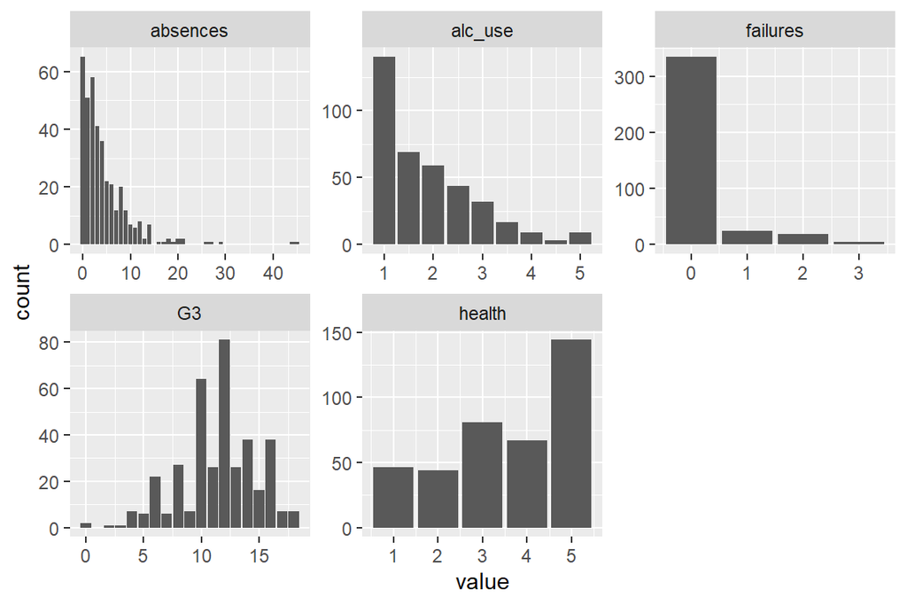

```r
library(ggplot2)
selected_variables <- select(data, one_of(c("failures", "health", "absences", "G3", "alc_use")))
gather(selected_variables) %>% ggplot(aes(value)) + facet_wrap("key", scales = "free") + geom_bar()
```

> From the graps we can clearly see the distributions of the variables. In case of variable “alc_use”, value 1 corresponds to very low consumption and value 5 to very high consumption. In case of variable “health, value 1 corresponds to very bad current health status and value 5 to very good current health status. Value 0 in variable”failures" means no failure at all.

### Exploring relationships between chosen variables and alcohol consumption

```r
library(GGally)
```

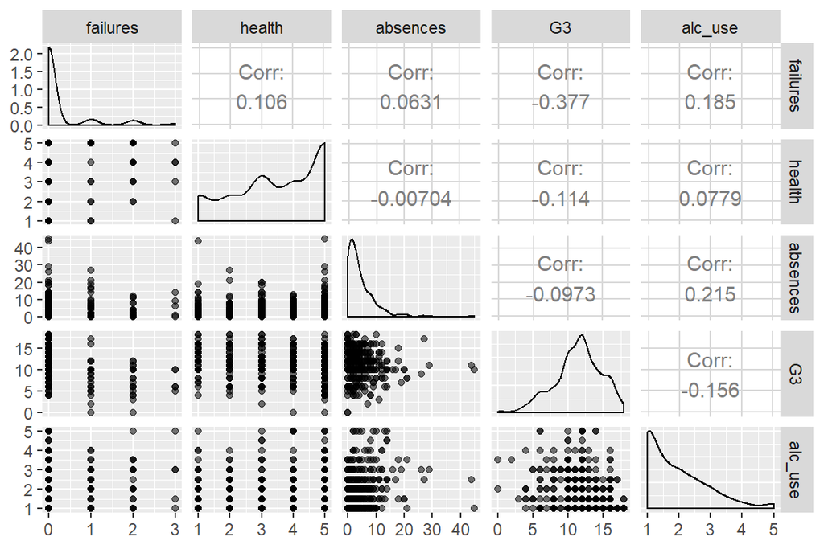

```r
library(ggplot2)

# Creating a plot matrix
selected_variables <- select(data, one_of(c("failures", "health", "absences", "G3", "alc_use")))
p <- ggpairs(selected_variables, mapping = aes(alpha=0.3), lower = list(combo = wrap("facethist", bins = 20)))
p
```

> From this graph we can see again distribution of each variable and also some other interesting things. We can see how variables are correlated to each other. From our chosen variables, the variable “absences” is the one which is influenced the most by the consumption of alcohol , since they have the highest value of correlation coefficient (0.215). Final grade (G3) is the only variable which is in negative relationship with the alcohol consumption. Those results are quite similar to my predictions, although one different and kind of interesting result is that health and alcohol consumption are positively correlated (although the correlation coefficient is very low).

## Task 5

### Applying logistic regression

```r
m <- glm(high_use ~ failures + health + absences + G3, data = data, family = "binomial")
summary(m)
```

```
##
## Call:
## glm(formula = high_use ~ failures + health + absences + G3, family = "binomial",
##     data = data)
##
## Deviance Residuals:
##     Min       1Q   Median       3Q      Max
## -2.3178  -0.7943  -0.7015   1.1814   1.9006
##
## Coefficients:
##             Estimate Std. Error z value Pr(>|z|)
## (Intercept) -1.13164    0.58665  -1.929 0.053731 .
## failures     0.39341    0.19912   1.976 0.048184 *
## health       0.07387    0.08602   0.859 0.390474
## absences     0.08458    0.02283   3.705 0.000212 ***
## G3          -0.04286    0.03791  -1.131 0.258225
## ---
## Signif. codes:  0 '***' 0.001 '**' 0.01 '*' 0.05 '.' 0.1 ' ' 1
##
## (Dispersion parameter for binomial family taken to be 1)
##
##     Null deviance: 465.68  on 381  degrees of freedom
## Residual deviance: 437.96  on 377  degrees of freedom
## AIC: 447.96
##
## Number of Fisher Scoring iterations: 4
```

> From the summary of the fitted model we can see that variales failures and absences are statistically significant. Variable failures is significant at 95% significance level, meanwhile variable absences at 99% with very low p-value. Other variables are statistically insignificant.

### Computing odds ratios and confidence intervals

```r
OR <- coef(m) %>% exp
CI <- confint(m) %>% exp
cbind(OR, CI)
```

```
##                    OR     2.5 %   97.5 %
## (Intercept) 0.3225027 0.1000825 1.004240
## failures    1.4820265 1.0036151 2.204355
## health      1.0766655 0.9109340 1.277264
## absences    1.0882646 1.0428902 1.140667
## G3          0.9580477 0.8892855 1.032188
```

## Task 6

### Exploring the predictive power of our model

```r
m2 <- glm(high_use ~ failures + absences + G3, data = data, family = "binomial")
probabilities <- predict(m2, type = "response")
data <- mutate(data, probability = probabilities)
data <- mutate(data, prediction = probability > 0.5)
table(high_use = data$high_use, prediction = data$prediction)
```

```
##         prediction
## high_use FALSE TRUE
##    FALSE   258   10
##    TRUE     98   16
```

> From the total of 382 students, our model correctly predicted 274 of them and 108 incorrectly.

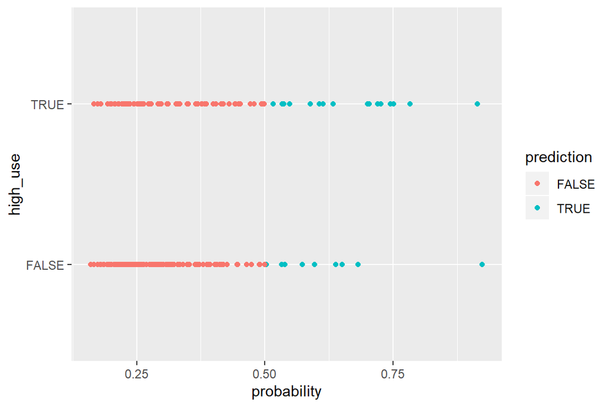

```r
g <- ggplot(data, aes(x = probability, y = high_use, col = prediction))
g + geom_point()
```

# Dimensionality reduction techniques

## Task 1

### Reading the data a showing summaries of the data

```r
Human_data <- read.csv(file = "human.csv")
summary(Human_data) # Summary of the data
```

```
##            X          Edu2.FM          Labo.FM          Edu.Exp
##  Afghanistan:  1   Min.   :0.1717   Min.   :0.1857   Min.   : 5.40
##  Albania    :  1   1st Qu.:0.7264   1st Qu.:0.5984   1st Qu.:11.25
##  Algeria    :  1   Median :0.9375   Median :0.7535   Median :13.50
##  Argentina  :  1   Mean   :0.8529   Mean   :0.7074   Mean   :13.18
##  Armenia    :  1   3rd Qu.:0.9968   3rd Qu.:0.8535   3rd Qu.:15.20
##  Australia  :  1   Max.   :1.4967   Max.   :1.0380   Max.   :20.20
##  (Other)    :149
##     Life.Exp          GNI            Mat.Mor         Ado.Birth
##  Min.   :49.00   Min.   :   581   Min.   :   1.0   Min.   :  0.60
##  1st Qu.:66.30   1st Qu.:  4198   1st Qu.:  11.5   1st Qu.: 12.65
##  Median :74.20   Median : 12040   Median :  49.0   Median : 33.60
##  Mean   :71.65   Mean   : 17628   Mean   : 149.1   Mean   : 47.16
##  3rd Qu.:77.25   3rd Qu.: 24512   3rd Qu.: 190.0   3rd Qu.: 71.95
##  Max.   :83.50   Max.   :123124   Max.   :1100.0   Max.   :204.80
##
##     Parli.F
##  Min.   : 0.00
##  1st Qu.:12.40
##  Median :19.30
##  Mean   :20.91
##  3rd Qu.:27.95
##  Max.   :57.50
##
```

### Distribution of the variables and relationships between them

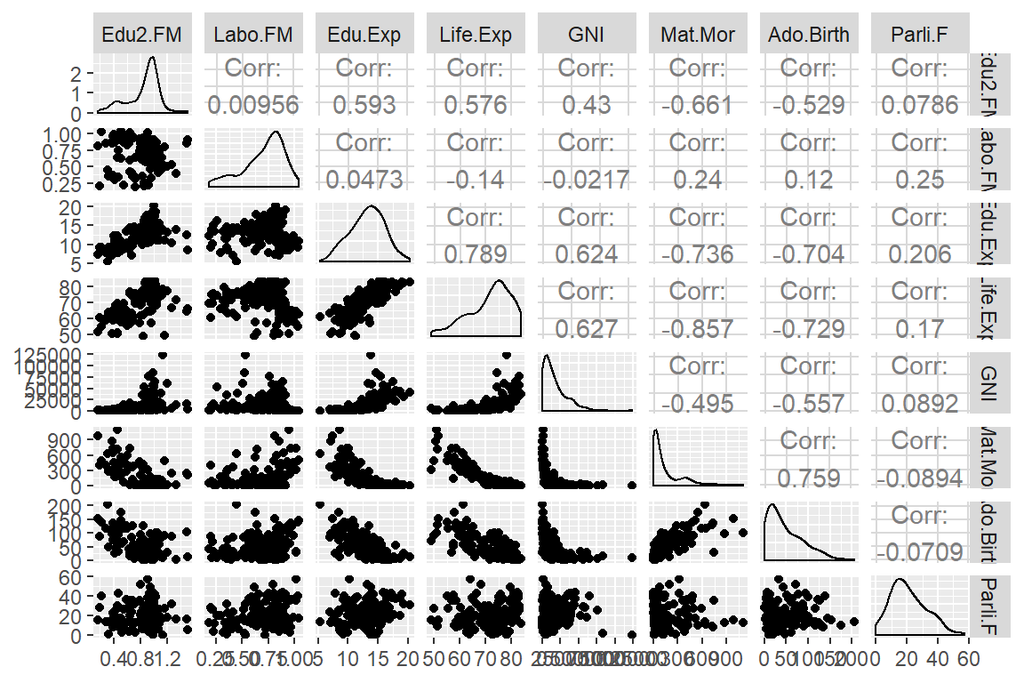

```r
library(GGally)
HumanData_numeric <- Human_data[,-1]

ggpairs(HumanData_numeric)
```

> Looking at a plot matrix above, we can nicely seee distribution of each variable on the diagonale and also correlation between each pair of variables. Some variables such a Edu2.FM and Edu.Exp have a nice normal distribution (although Edu.2FM is slightly skewed to the left). GNI is strongly skewed to the right, which means that the gross national income per capita is quite small on average. Variable Mat.Mor is also skewed to hte right meaning that maternal mortality ration is quite low in most countries. With regard to relationships between variables, we can see that are mostly positive relationships. Strong positive relationship is between life expectancy at birth and expected years of schooling. The strongest negative relationship is between maternal mortality ration and life expectancy at birth, here the correlation coefficient is equal to -0.857.

## Task 2

### Performing principal component analysis

```r
pca <- prcomp(HumanData_numeric)
summary(pca) # From summary can be seen that almost all variation can be explained by PC1
```

```
## Importance of components:
##                              PC1      PC2   PC3   PC4   PC5   PC6    PC7
## Standard deviation     1.854e+04 185.5219 25.19 11.45 3.766 1.566 0.1912
## Proportion of Variance 9.999e-01   0.0001  0.00  0.00 0.000 0.000 0.0000
## Cumulative Proportion  9.999e-01   1.0000  1.00  1.00 1.000 1.000 1.0000
##                           PC8
## Standard deviation     0.1591
## Proportion of Variance 0.0000
## Cumulative Proportion  1.0000
```

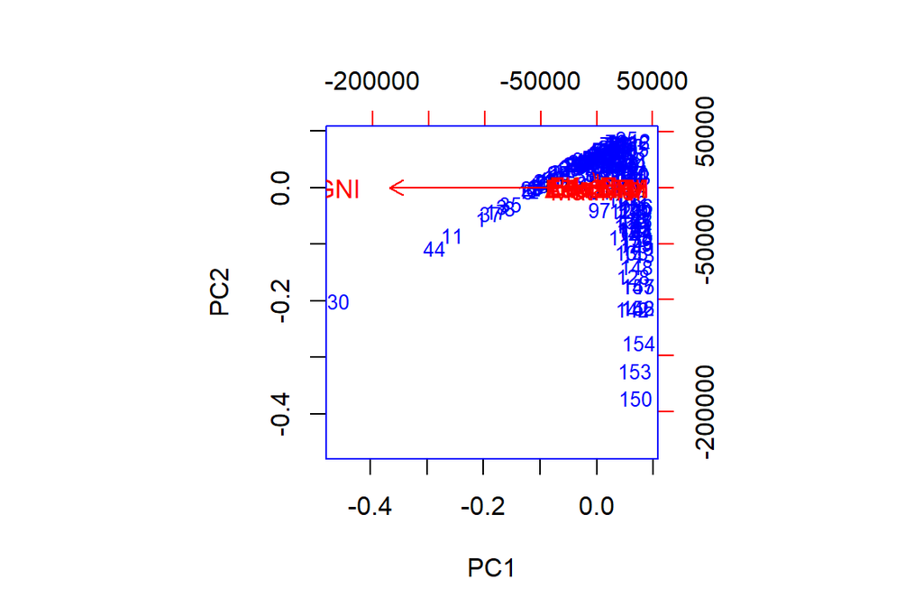

```r
biplot(pca, choices = 1:2, cex = c(0.8, 1), col = c("blue", "red"))
```

## Task 3

### Standardizing variables

```r
HumanData_st <- scale(HumanData_numeric)
summary(HumanData_st)
```

```
##     Edu2.FM           Labo.FM           Edu.Exp           Life.Exp
##  Min.   :-2.8189   Min.   :-2.6247   Min.   :-2.7378   Min.   :-2.7188
##  1st Qu.:-0.5233   1st Qu.:-0.5484   1st Qu.:-0.6782   1st Qu.:-0.6425
##  Median : 0.3503   Median : 0.2316   Median : 0.1140   Median : 0.3056
##  Mean   : 0.0000   Mean   : 0.0000   Mean   : 0.0000   Mean   : 0.0000
##  3rd Qu.: 0.5958   3rd Qu.: 0.7350   3rd Qu.: 0.7126   3rd Qu.: 0.6717
##  Max.   : 2.6646   Max.   : 1.6632   Max.   : 2.4730   Max.   : 1.4218
##       GNI             Mat.Mor          Ado.Birth          Parli.F
##  Min.   :-0.9193   Min.   :-0.6992   Min.   :-1.1325   Min.   :-1.8203
##  1st Qu.:-0.7243   1st Qu.:-0.6496   1st Qu.:-0.8394   1st Qu.:-0.7409
##  Median :-0.3013   Median :-0.4726   Median :-0.3298   Median :-0.1403
##  Mean   : 0.0000   Mean   : 0.0000   Mean   : 0.0000   Mean   : 0.0000
##  3rd Qu.: 0.3712   3rd Qu.: 0.1932   3rd Qu.: 0.6030   3rd Qu.: 0.6127
##  Max.   : 5.6890   Max.   : 4.4899   Max.   : 3.8344   Max.   : 3.1850
```

> Mean became 0.

```r
pca_st <- prcomp(HumanData_st)
summary(pca_st)
```

```
## Importance of components:
##                           PC1    PC2     PC3     PC4     PC5     PC6
## Standard deviation     2.0708 1.1397 0.87505 0.77886 0.66196 0.53631
## Proportion of Variance 0.5361 0.1624 0.09571 0.07583 0.05477 0.03595
## Cumulative Proportion  0.5361 0.6984 0.79413 0.86996 0.92473 0.96069
##                            PC7     PC8
## Standard deviation     0.45900 0.32224
## Proportion of Variance 0.02634 0.01298
## Cumulative Proportion  0.98702 1.00000
```

> Comparing this summary to the summary without standardization, variation is in this case better (more evenly) distributed across the components. After standardization our results seems much more satisfying, since we can better see how each variable affect the variations in the model.

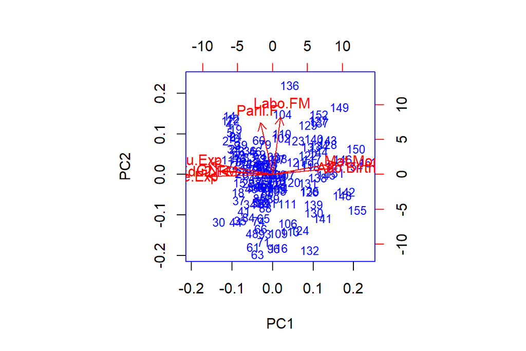

```r
biplot(pca_st, choices = 1:2, cex = c(0.8, 1), col=c("blue","red"))
```

## Task 4

### Interpretations of the first two principal component dimensions

> In general it holds that the first principal component (PC1) captures the most variation in the data and the second principal component (PC2) captures the second most variation in the data. From the last graph we cann see that variables such as Mat.Mor and Ado.Birth have large positive influence on PC1. On the other hand, variables such as Edu.Exp, GNI, Edu2.PM and Life.Exp have negative influence on PC1. Those variables I just mentioned have almost no influence on PC2. Variables Parli.F and Labo.FM have a positive influence on PC2. Also note that from summary we can see that PC1 and PC2 together explains approximately 70% of the variation. From the angles between arrows we can say what is the correlation between the two corresponding features. For example there is high positive correlation between variables Mat.Mor and Ado.Birht, since there is small angle between their arrows.There is also almost no correlation between some variables. For instance arrow corresponding to Mat.Mor. is almost orthogonal to the arrow corresponding to Parli.F, thus there is very low correlation between those two variables.

## Task 5

### Loading the tea dataset and exploring the data

```r
if (!require("devtools")) install.packages("devtools")
library(devtools)
install_github("husson/FactoMineR")
```

[output not shown]

[output not shown]

```r
library(FactoMineR)
library(dplyr)
library(tidyr)
data(tea)
str(tea)
```

```
## 'data.frame':    300 obs. of  36 variables:
##  $ breakfast       : Factor w/ 2 levels "breakfast","Not.breakfast": 1 1 2 2 1 2 1 2 1 1 ...
##  $ tea.time        : Factor w/ 2 levels "Not.tea time",..: 1 1 2 1 1 1 2 2 2 1 ...
##  $ evening         : Factor w/ 2 levels "evening","Not.evening": 2 2 1 2 1 2 2 1 2 1 ...
##  $ lunch           : Factor w/ 2 levels "lunch","Not.lunch": 2 2 2 2 2 2 2 2 2 2 ...
##  $ dinner          : Factor w/ 2 levels "dinner","Not.dinner": 2 2 1 1 2 1 2 2 2 2 ...
##  $ always          : Factor w/ 2 levels "always","Not.always": 2 2 2 2 1 2 2 2 2 2 ...
##  $ home            : Factor w/ 2 levels "home","Not.home": 1 1 1 1 1 1 1 1 1 1 ...
##  $ work            : Factor w/ 2 levels "Not.work","work": 1 1 2 1 1 1 1 1 1 1 ...
##  $ tearoom         : Factor w/ 2 levels "Not.tearoom",..: 1 1 1 1 1 1 1 1 1 2 ...
##  $ friends         : Factor w/ 2 levels "friends","Not.friends": 2 2 1 2 2 2 1 2 2 2 ...
##  $ resto           : Factor w/ 2 levels "Not.resto","resto": 1 1 2 1 1 1 1 1 1 1 ...
##  $ pub             : Factor w/ 2 levels "Not.pub","pub": 1 1 1 1 1 1 1 1 1 1 ...
##  $ Tea             : Factor w/ 3 levels "black","Earl Grey",..: 1 1 2 2 2 2 2 1 2 1 ...
##  $ How             : Factor w/ 4 levels "alone","lemon",..: 1 3 1 1 1 1 1 3 3 1 ...
```

[output cut: 22 more lines]

```r
dim(tea)
```

```
## [1] 300  36
```

```r
chosen_tea <- tea[,c(3,6,11,14)]
str(chosen_tea)
```

```
## 'data.frame':    300 obs. of  4 variables:
##  $ evening: Factor w/ 2 levels "evening","Not.evening": 2 2 1 2 1 2 2 1 2 1 ...
##  $ always : Factor w/ 2 levels "always","Not.always": 2 2 2 2 1 2 2 2 2 2 ...
##  $ resto  : Factor w/ 2 levels "Not.resto","resto": 1 1 2 1 1 1 1 1 1 1 ...
##  $ How    : Factor w/ 4 levels "alone","lemon",..: 1 3 1 1 1 1 1 3 3 1 ...
```

```r
mca_model <- MCA(chosen_tea)
```

[figure not shown]

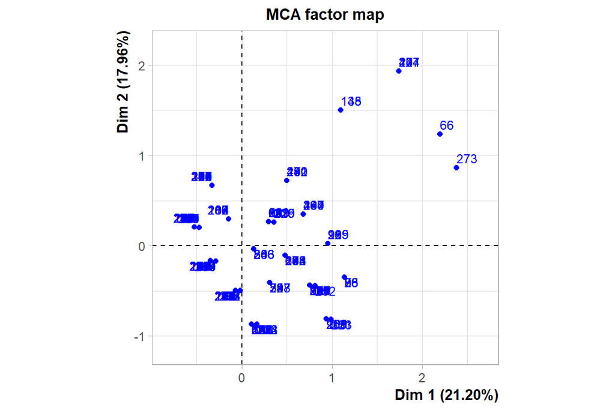

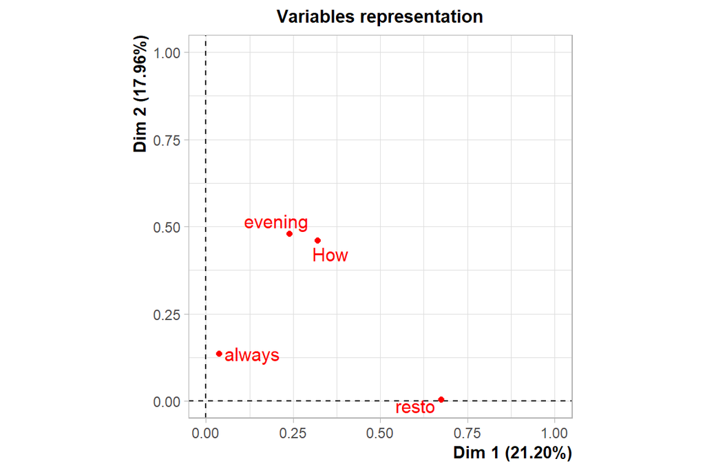

```r
summary(mca_model)
```

```
##
## Call:
## MCA(X = chosen_tea)
##
##
## Eigenvalues
##                        Dim.1   Dim.2   Dim.3   Dim.4   Dim.5   Dim.6
## Variance               0.318   0.269   0.255   0.250   0.238   0.169
## % of var.             21.204  17.964  17.010  16.666  15.884  11.272
## Cumulative % of var.  21.204  39.168  56.178  72.844  88.728 100.000
##
## Individuals (the 10 first)
##                Dim.1    ctr   cos2    Dim.2    ctr   cos2    Dim.3    ctr
## 1           | -0.528  0.293  0.575 |  0.208  0.054  0.089 | -0.299  0.117
## 2           | -0.328  0.113  0.083 |  0.667  0.550  0.344 |  0.595  0.463
## 3           |  0.755  0.598  0.395 | -0.436  0.235  0.132 | -0.463  0.281
## 4           | -0.528  0.293  0.575 |  0.208  0.054  0.089 | -0.299  0.117
## 5           |  0.110  0.013  0.010 | -0.868  0.931  0.638 |  0.187  0.046
## 6           | -0.528  0.293  0.575 |  0.208  0.054  0.089 | -0.299  0.117
## 7           | -0.528  0.293  0.575 |  0.208  0.054  0.089 | -0.299  0.117
## 8           |  0.129  0.017  0.010 | -0.036  0.002  0.001 |  0.478  0.299
## 9           | -0.328  0.113  0.083 |  0.667  0.550  0.344 |  0.595  0.463
## 10          | -0.071  0.005  0.006 | -0.494  0.302  0.293 | -0.416  0.226
##               cos2
## 1            0.184 |
## 2            0.274 |
## 3            0.149 |
## 4            0.184 |
## 5            0.030 |
## 6            0.184 |
## 7            0.184 |
## 8            0.139 |
## 9            0.274 |
## 10           0.208 |
##
## Categories
##                 Dim.1     ctr    cos2  v.test     Dim.2     ctr    cos2
## evening     |   0.677  12.368   0.240   8.465 |  -0.958  29.215   0.480
## Not.evening |  -0.354   6.467   0.240  -8.465 |   0.501  15.275   0.480
## always      |   0.269   1.948   0.038   3.359 |  -0.509   8.251   0.135
```

[output cut: 10 more lines]

```
## always       -6.364 |   0.800  21.513   0.334   9.998 |
## Not.always    6.364 |  -0.418  11.248   0.334  -9.998 |
## Not.resto    -0.920 |   0.025   0.046   0.002   0.731 |
## resto         0.920 |  -0.071   0.129   0.002  -0.731 |
## alone        -7.141 |  -0.292   5.439   0.159  -6.886 |
## lemon        -1.904 |  -0.728   5.705   0.065  -4.423 |
## milk          5.792 |   1.514  47.169   0.609  13.498 |
## other         9.631 |  -1.599   7.515   0.079  -4.862 |
##
## Categorical variables (eta2)
##               Dim.1 Dim.2 Dim.3
## evening     | 0.240 0.480 0.013 |
## always      | 0.038 0.135 0.334 |
## resto       | 0.675 0.003 0.002 |
## How         | 0.320 0.460 0.672 |
```

> From the summary above we can get some interestng things. From eigenvalues part we can see percentage of variances retained by each dimension. Individuals part tells us the percentge contribution of each variable on the dimension. From the column v.test we can say wheather the variable is statistically significant from zero or not. In our case, almost all variables are statistically significant in each dimension. Section categorical variables tells us link (correlation) between the variable and dimension. In our case there is not a strong link between variables and dimensions. The strongest one is between resto variable a first dimension, where the correlation equals 0.675.

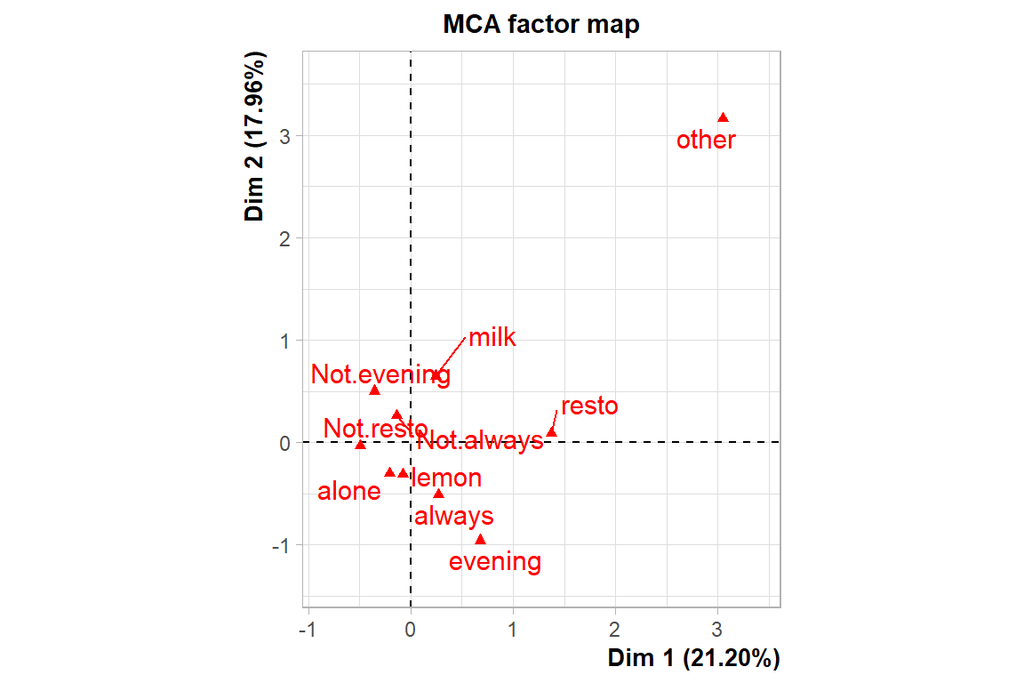

```r
plot(mca_model, invisible=c("ind"))
```

# Analysis of longitudinal data

## Task 1

### Reading the data

```r
RATS <- read.csv("RATSL.csv")

sapply(RATS, class)
```

```
##        ID     Group      time      gram
## "integer" "integer"  "factor" "integer"
```

> Categorical variables ID and Group are still in integer form, we need to convert them into the factors. Also note that time is a factor variable, we need to convert it into numeric one.

```r
RATS$ID <- as.factor(RATS$ID)
RATS$Group <- as.factor(RATS$Group)

RATS$time <- as.numeric(RATS$time)

sapply(RATS, class)
```

```
##        ID     Group      time      gram
##  "factor"  "factor" "numeric" "integer"
```

### Drawing the plot of RATS

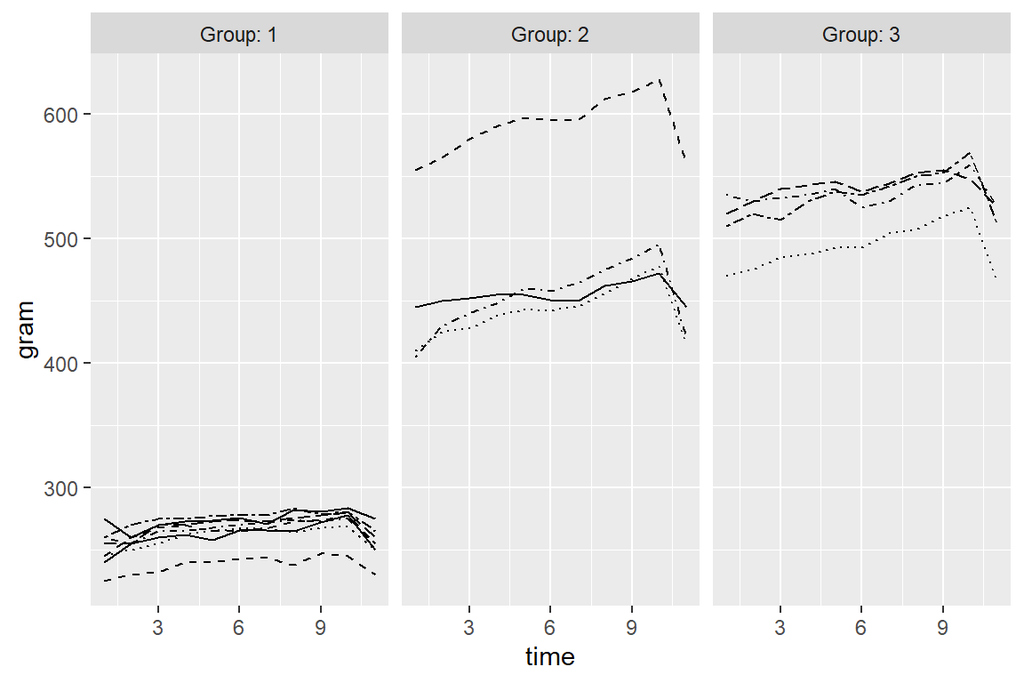

```r
library(ggplot2)

ggplot(RATS, aes(x = time, y = gram, linetype = ID)) +
  geom_line() +
  scale_linetype_manual(values = rep(1:10, times=4)) +
  facet_grid(. ~ Group, labeller = label_both) +
  theme(legend.position = "none") +
  scale_y_continuous(limits = c(min(RATS$gram), max(RATS$gram)))
```

### Standardizing the variable gram

```r
library(dplyr)
library(tidyr)

RATS <- RATS %>%
  group_by(time) %>%
  mutate(std_gram = (gram - mean(gram))/sd(gram) ) %>%
  ungroup()

glimpse(RATS)
```

```
## Observations: 176
## Variables: 5
## $ ID       <fct> 1, 2, 3, 4, 5, 6, 7, 8, 9, 10, 11, 12, 13, 14, 15, 16...
## $ Group    <fct> 1, 1, 1, 1, 1, 1, 1, 1, 2, 2, 2, 2, 3, 3, 3, 3, 1, 1,...
## $ time     <dbl> 1, 1, 1, 1, 1, 1, 1, 1, 1, 1, 1, 1, 1, 1, 1, 1, 11, 1...
## $ gram     <int> 240, 225, 245, 260, 255, 260, 275, 245, 410, 405, 445...
## $ std_gram <dbl> -1.0011429, -1.1203857, -0.9613953, -0.8421525, -0.88...
```

### Drawing the plot of RATS with standardised variable gram

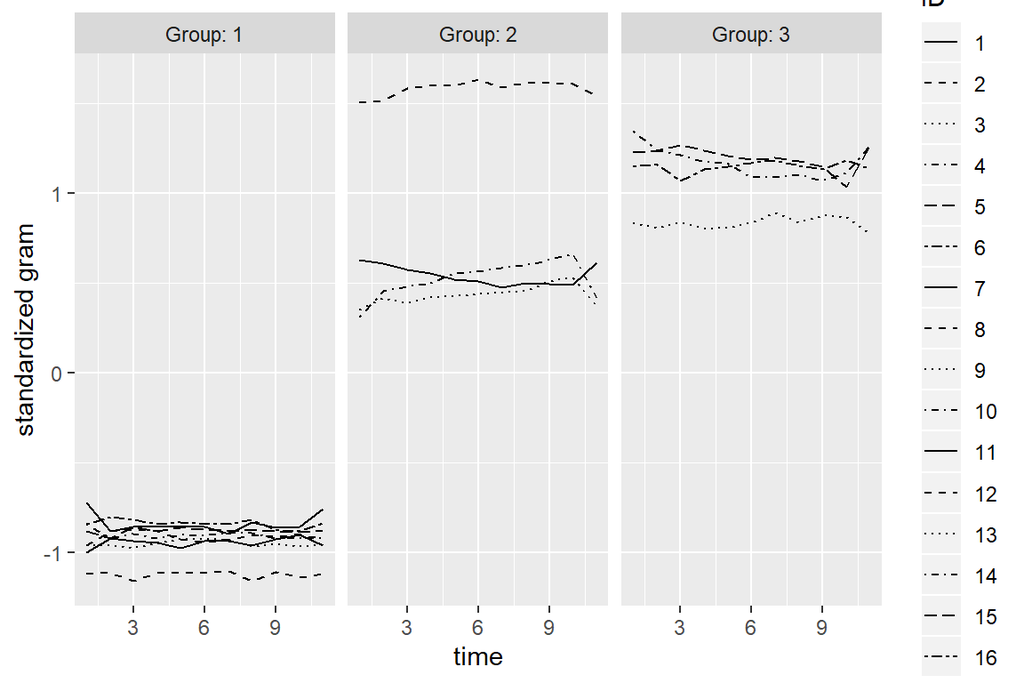

```r
ggplot(RATS, aes(x = time, y = std_gram, linetype = ID)) +
  geom_line() +
  scale_linetype_manual(values = rep(1:10, times=4)) +
  facet_grid(. ~ Group, labeller = label_both) +
  scale_y_continuous(name = "standardized gram")
```

> From the standardized curves we can better see the tracking phenomenon. Comparing this graph to the one with unstandardized values, the gram values of the second and third group stay the same over the whole period.

### Summarazing data with mean and standard error of gram by group and time and ploting the mean profiles

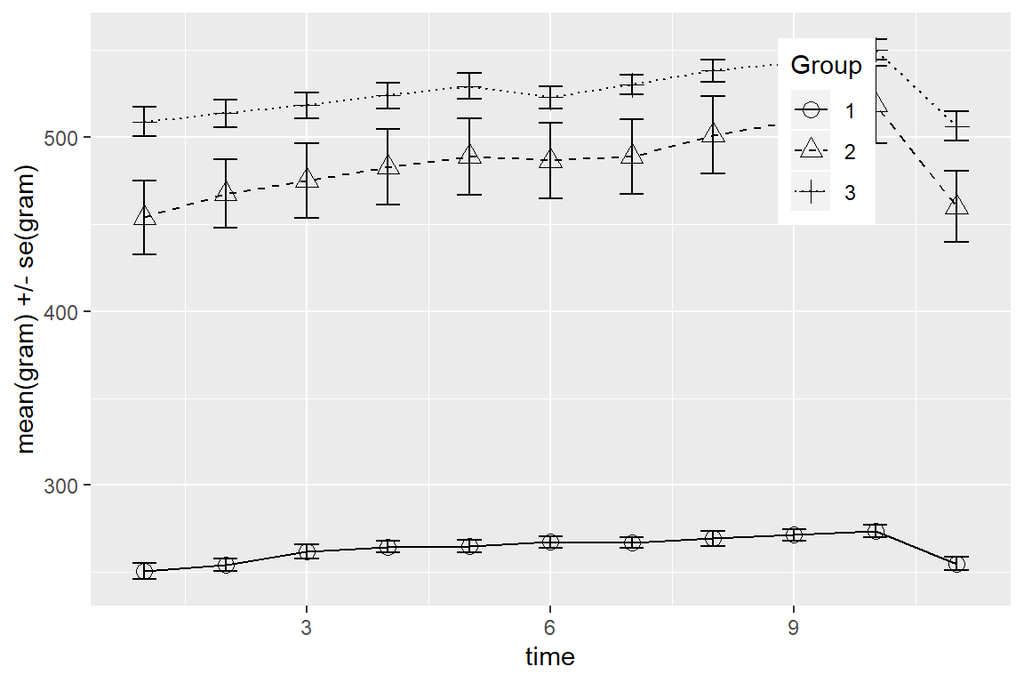

```r
n <- RATS$time %>% unique() %>% length()

RATSS <- RATS %>%
  group_by(Group, time) %>%
  summarise( mean = mean(gram), se = sd(gram)/sqrt(n) ) %>%
  ungroup()

ggplot(RATSS, aes(x = time, y = mean, linetype = Group, shape = Group)) +
  geom_line() +
  scale_linetype_manual(values = c(1,2,3)) +
  geom_point(size=3) +
  scale_shape_manual(values = c(1,2,3)) +
  geom_errorbar(aes(ymin = mean - se, ymax = mean + se, linetype="1"), width=0.3) +
  theme(legend.position = c(0.8,0.8)) +
  scale_y_continuous(name = "mean(gram) +/- se(gram)")
```

> The mean profiles of the second and third group follow the same pattern, although the mean profile of the third group is little bit higher on average. On the other hand, there is a huge difference between the first group and the other two groups with respect to the mean gram values, the mean profile of the first group is much lower comparing to other groups.

### Creating a summary data by group and ID with mean as the summary variable and drawing a boxplot of the mean versus Group

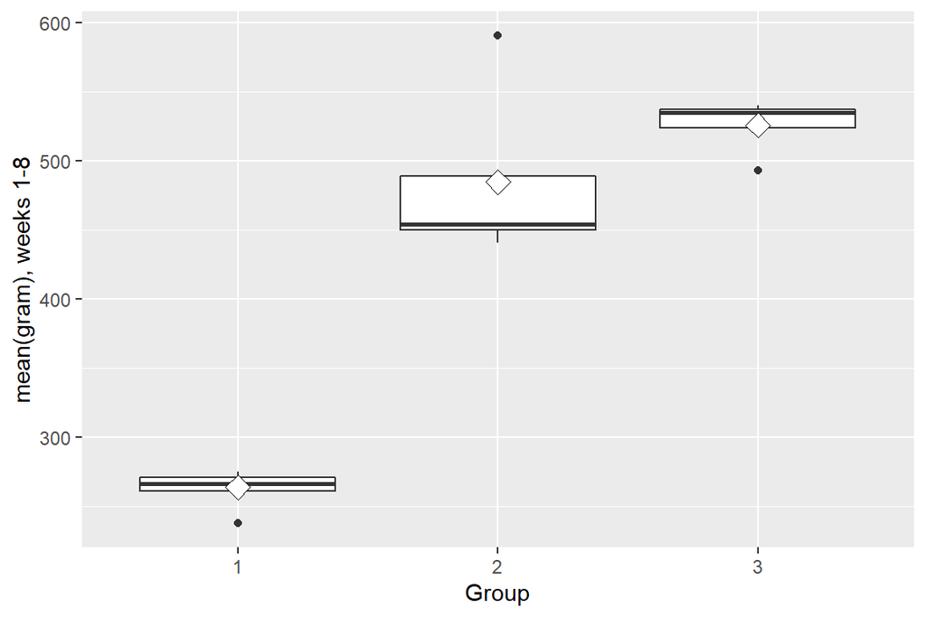

```r
RATSSS <- RATS %>%
  filter(time > 0) %>%
  group_by(Group, ID) %>%
  summarise( mean=mean(gram) ) %>%
  ungroup()

ggplot(RATSSS, aes(x = Group, y = mean)) +
  geom_boxplot() +
  stat_summary(fun.y = "mean", geom = "point", shape=23, size=4, fill = "white") +
  scale_y_continuous(name = "mean(gram), weeks 1-8")
```

> The black dots indicates, that there is an outlier in each group. Regarding the first and third group, the outlier is lower than other values. On the other hand, in the second group the outlier is much higher with a gram value equal almost to 600. We should consider remove those outliers, so they do not bias our results. Note also that the distribution of the second group is somewhat skewed.

## Task 2

### Reading the data

```r
BPRS <- read.csv("BPRSL.csv")

sapply(BPRS, class)
```

```
## treatment   subject     weeks      bprs
## "integer" "integer"  "factor" "integer"
```

> Categorical variables treatment and subject are still in integer form, we need to convert them into the factors. Also note that variable weeks is a factor variable, we need to convert it into numeric one.

```r
BPRS$treatment <- as.factor(BPRS$treatment)
BPRS$subject <- as.factor(BPRS$treatment)

BPRS$weeks <- as.numeric(BPRS$weeks)

sapply(BPRS, class)
```

```
## treatment   subject     weeks      bprs
##  "factor"  "factor" "numeric" "integer"
```